# Social Vulnerability in Virginia Counties: A Statistical Learning Approach

# RQ2: Main Dimensions of Vulnerability and County Grouping

The second question asks how the 17 indicators collapse into a smaller number of dimensions and whether counties cluster into recognizable profiles. We use **PCA** on the standardized predictors, then cluster counties using both **K-means** (a partitional method) and **Ward.D2 hierarchical clustering** (an agglomerative method). Comparing two clustering algorithms is a fairness safeguard: if the two methods agree, the resulting county profiles are not an artifact of one algorithm’s bias. We measure agreement using the Adjusted Rand Index (Hubert & Arabie, 1985).

## Principal Component Analysis

Table 8. Variance Explained by the First Eight Principal Components

| PC | % Variance Explained | Cumulative % |
| --- | --- | --- |
| 1 | 29.31 | 29.31 |
| 2 | 24.03 | 53.35 |
| 3 | 11.24 | 64.58 |
| 4 | 8.14 | 72.73 |
| 5 | 5.96 | 78.69 |
| 6 | 4.43 | 83.12 |
| 7 | 3.55 | 86.67 |
| 8 | 2.80 | 89.47 |

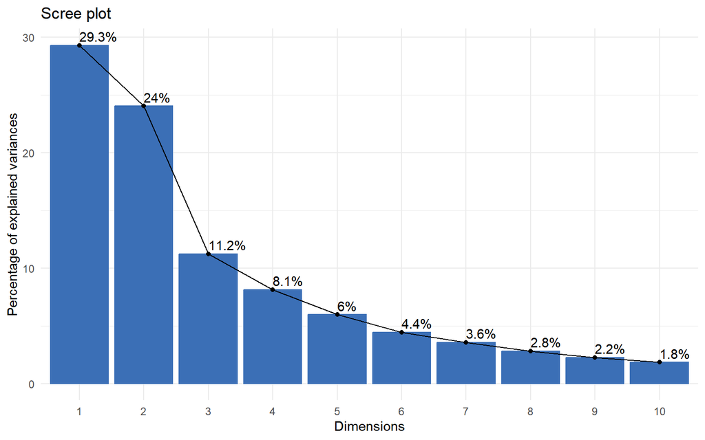

Figure 7. PCA scree plot. The first six components explain over 80% of total variance, but PC1 alone explains only ~29%, indicating that vulnerability in Virginia is not dominated by a single dimension.

Figure 7 reveals a gradual decline in eigenvalues rather than a sharp elbow. PC1 explains only about 29% of total variance and PC2 explains about 24%, and six components are required to clear the 80% cumulative threshold. This pattern indicates that vulnerability information is genuinely distributed across multiple dimensions in this dataset rather than concentrated in one or two leading axes — an empirical finding that supports the multi-theme structure of the SVI framework.

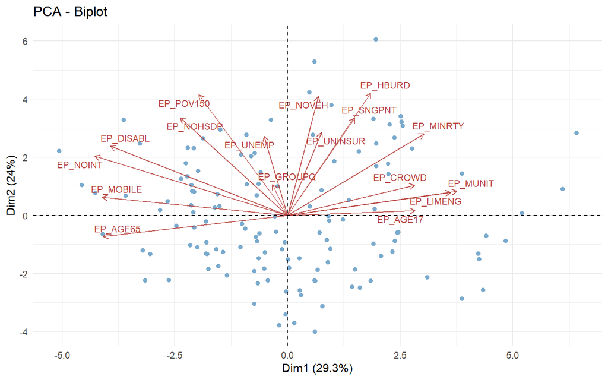

Figure 8. PCA biplot of counties (points) and predictor loadings (arrows) on PC1–PC2. PC1 separates counties along an urban-versus-rural axis (multi-unit housing, limited English, crowded housing point opposite to mobile homes, no internet, and elderly population); PC2 captures economic distress (poverty, housing burden, uninsured).

Figure 8 makes the geometric structure of PC1–PC2 visually concrete. The loading arrows for No Internet Access, Mobile Homes, and Age 65 or Older point to one side of PC1, while Multi-Unit Housing, Limited English, and Crowded Housing point to the opposite side, confirming that PC1 is best read as an urban–rural contrast rather than a vulnerability gradient. The vertical spread along PC2 is dominated by Poverty Rate, Housing Cost Burden, and No Vehicle Access, supporting the interpretation of PC2 as an economic-distress dimension that operates orthogonally to the urban–rural axis.

Table 9. PCA Loadings for the First Three Components

| Variable | PC1 | PC2 | PC3 |
| --- | --- | --- | --- |
| No Internet Access | -0.366 | 0.193 | -0.072 |
| Mobile Homes | -0.352 | 0.059 | -0.178 |
| Age 65 or Older | -0.351 | -0.069 | -0.129 |
| Disability Rate | -0.336 | 0.225 | -0.092 |
| Multi-Unit Housing | 0.322 | 0.078 | 0.162 |
| Limited English | 0.310 | 0.074 | -0.325 |
| Minority Population | 0.259 | 0.265 | -0.007 |
| Age 17 or Younger | 0.243 | 0.015 | -0.347 |
| Crowded Housing | 0.242 | 0.098 | -0.359 |
| No High School Diploma | -0.204 | 0.318 | -0.271 |
| Poverty Rate | -0.168 | 0.392 | 0.073 |
| Housing Cost Burden | 0.158 | 0.397 | 0.179 |
| Single-Parent Households | 0.128 | 0.317 | 0.120 |
| Uninsured Rate | 0.065 | 0.270 | -0.403 |
| No Vehicle Access | 0.059 | 0.387 | 0.209 |
| Unemployment Rate | -0.044 | 0.258 | 0.073 |
| Group Quarters | -0.028 | 0.100 | 0.469 |

PC1 (~29% of variance) loads negatively on rural-style indicators (No Internet, Mobile Homes, Age 65+) and positively on urban-style indicators (Multi-Unit Housing, Limited English) — it is best read as an **urban–rural axis** rather than an “overall vulnerability” axis. PC2 (~24%) loads positively on classical *economic distress* indicators (Poverty, Housing Cost Burden, No Vehicle, Single-Parent Households). PC3 captures a residual contrast involving Group Quarters and Uninsured Rate. Because no single PC dominates, the SVI’s multidimensional design appears empirically justified.